# pstat 131 hw 3

```r
library(tidymodels)
library(tidyverse)
library(ISLR)
library(ISLR2)
library(discrim)
library(poissonreg)
library(corrr)
library(corrplot)
library(klaR)
library(pROC)
tidymodels_prefer()
```

```r
titanic<- read.csv('/Users/ankitapattnaik/Downloads/homework-3/data/titanic.csv', stringsAsFactor=T)
titanic.cdbk<- read_csv('/Users/ankitapattnaik/Downloads/homework-3/data/titanic_codebook.txt')
```

1. Split the data, stratifying on the outcome variable, survived. You should choose the proportions to split the data into. Verify that the training and testing data sets have the appropriate number of observations. Take a look at the training data and note any potential issues, such as missing data.

```r
set.seed(3435)

titanic_split <- initial_split(titanic, prop = 0.70,
                                strata = survived)
titanic_train <- training(titanic_split)
titanic_test <- testing(titanic_split)
```

Why is it a good idea to use stratified sampling for this data? - It is a good idea to use stratified sampling for this data because by taking a part of the data, we can make assumptions based on demographics and draw conclusions on all the data based off the stratified chunk. This allows us to work with less data and be more clean with our work, that way we can draw conclusions on the population as a whole.

2. Using the training data set, explore/describe the distribution of the outcome variable survived.

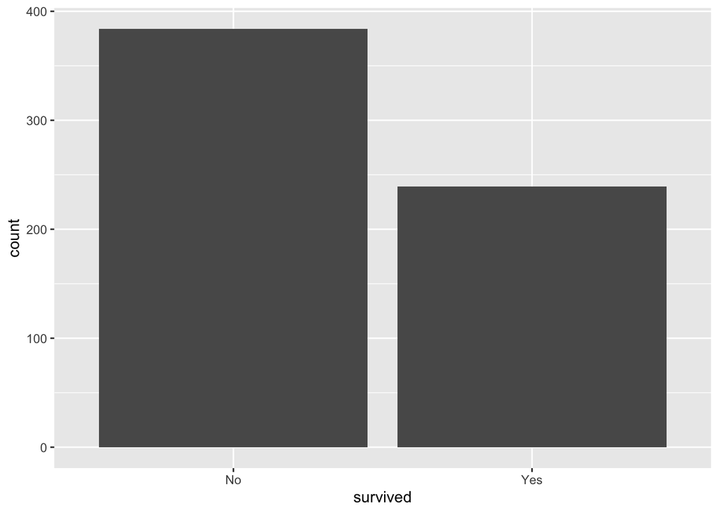

```r
titanic_train %>%
  ggplot(aes(x = survived)) +
  geom_bar()
```

- Less people survived than not. We see this through a bar plot.
3. Using the training data set, create a correlation matrix of all continuous variables. Create a visualization of the matrix, and describe any patterns you see.

```r
cor_titanic <- titanic_train %>%
  select(where(is.numeric)) %>%
  correlate()
```

```
##
## Correlation method: 'pearson'
## Missing treated using: 'pairwise.complete.obs'
```

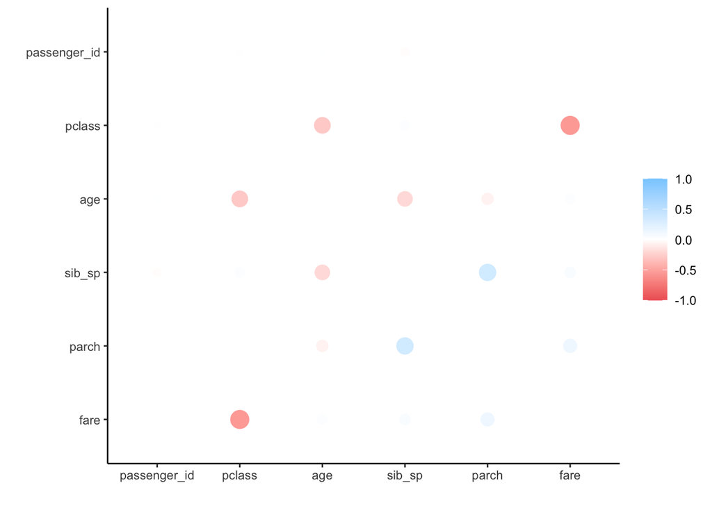

```r
rplot(cor_titanic)
```

4. Using the training data, create a recipe predicting the outcome variable survived. Include the following predictors: ticket class, sex, age, number of siblings or spouses aboard, number of parents or children aboard, and passenger fare.